# The Politics of Corruption

Lecture 11: Kleptocracy — Where the Money Goes

Bogdan G. Popescu

bgpopescu@tec.mx

Tecnológico de Monterrey

## Remember Diego

Last week this deal was the whole story: cheap land for a share of the profits, and a city that received less than it should have.

- The share went to the official’s brother. Already the money sits in someone else’s name
- The city lost money it had not yet collected: a discount on land. Today the money has already been paid out of a budget
- Diego’s towers did get built.
- This week, nothing gets built with the missing money, and it does not stay in the country

So today:

- how does the public money get out?
- how could anyone count the money?
- where does the money end up?

## Today

**Public money is stolen. Where does it go?**

- Explain why revenue that skips the taxpayer escapes scrutiny
- Trace a stolen payment from a public budget to a foreign asset
- Say why beneficial ownership is the binding question at every step

Three steps: - **unearned revenue** - **capture** - **concealment**.

# I. The Fiscal Contract

## Two governments, one budget

Both raise 100 billion dollars a year.

- **Government A** collects it from millions of taxpayers
- **Government B** sells oil to foreign buyers
- A must persuade millions of people to keep paying
- B needs far less from its own citizens

Same budget. Government B has far less reason to bargain.

## Who is in the circuit?

[figure not shown]

In A the citizen sits inside the loop, and the loop is what keeps the money coming. In B nothing points at them.

## The fiscal contract

Collection is cheaper when people believe it is fair, so consent is worth buying. Scrutiny is the price.

Political scientists call that bargain the **fiscal contract**.

This is a tendency rather than a law. Plenty of states have taxed heavily and coercively.

Government B never has to strike that bargain. There are two words for what it has instead.

## Windfall and rent

**Windfall**

Money a government never had to ask its own citizens for.

Both governments a moment ago raised 100 billion. A had to persuade millions of taxpayers. B just sold oil to foreigners.

**Rent**

The gap between what something costs to produce and what it sells for.

A barrel of oil costs **$20** to lift and sells for **$80**. The $20 pays for the work. The **$60** is there because the oil was already in the ground.

A landlord’s income is called rent for the same reason: it comes from owning something, not from doing something.

Every case in this lecture is someone taking a share of a rent that arrived as a windfall.

## Does the pattern show up in the data?

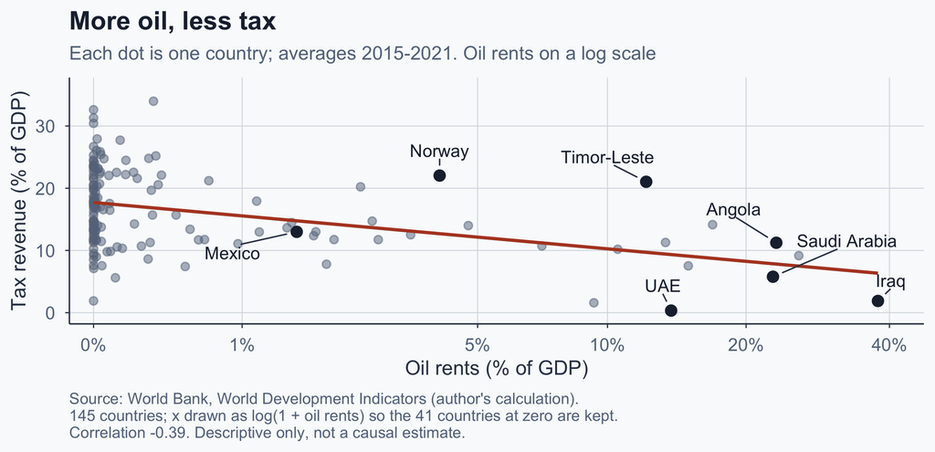

A correlation, which cannot show causation. The direction is the one theory predicts.

## From oil to aid

The problem is not oil. It is **where government revenue comes from**.

- When governments depend on taxpayers, citizens have leverage
- When money arrives from outside, that leverage can weaken
- **Foreign aid** creates a similar problem

But aid is supposed to build roads, clinics and schools.

**If a donor gives a government more money, does more actually reach the people it is meant to help?**

# II. Catching the Money as It Leaves

## Aid is a windfall too

- Aid arrives from abroad; the government did not have to raise it from its own taxpayers
- Like oil revenue, it reaches the state without first being bargained out of citizens
- In the 50 most aid-dependent countries in Svensson’s data, aid financed **53.8% of central government spending**

So aid raises the same broad problem as oil. But Svensson’s argument is sharper: **more outside money can mean fewer clinics, not more.**

Aid as a share of central government expenditure, 1975-1995. Reported in Svensson (2000, p. 438), citing World Bank (1998).

## A donor doubles the budget

> A health ministry has **100** to spend on clinics. A donor adds **100** more. Two state governors each want the new clinics built in their own state.

**Neither can simply take the money. So each one spends to win it:**

- Flies to the capital, hires consultants, commissions a feasibility study, puts staff on the minister full-time
- Every dollar and every official hour spent that way builds no clinic

**So how much of the 200 reaches a clinic?**

## More money, fewer clinics?

**A thought experiment.** Suppose both governors fight for the bigger pot:

- The budget is a **common pool**: the bigger it grows, the more it is worth fighting over
- Svensson (2000): this *can* outweigh the extra money, unless the donor can **credibly** threaten to withhold

## What is the World Bank?

You cannot open an account there.

- Its member governments own it, Mexico among them
- It lends and grants money to the **governments** of poorer countries
- For projects: roads, clinics, schools, power
- Two arms: **IDA**, the International Development Association, for the poorest countries
- And **IBRD**, the International Bank for Reconstruction and Development, for middle-income ones

The money lands in a finance ministry. From there, officials decide who actually gets paid.

## So how does the money leave?

Earlier the governors could not simply take the money. Suppose now that one official can.

> A ministry has **$10 million** of World Bank money for a rural road.
- An official awards the contract to a firm, on an understanding
- The firm bills the full **$10 million** and builds **$6 million** of road
- It keeps part of the **$4 million** difference and sends the official **$2.5 million**

That return payment is a **kickback**: a secret payment that someone receives in exchange for giving another person or company a contract or a special favor.

Every document is complete, approved, and legal on its face. **The theft is the paperwork**.

## Wouldn’t someone notice?

Nothing goes missing. The ministry paid **$10 million** and a road exists.

- A routine reconciliation finds nothing. The loss is in the **price**, not in the ledger
- To see it you must know the road should have cost **$6 million**
- That needs an engineer’s estimate, an inspection, and someone able to act
- And the kickback left the firm’s account, which the ministry cannot audit

So it often is caught, but late, and usually by journalists or a foreign prosecutor.

## Every bank knows who you are

Open an account anywhere and the bank must record who you are. Almost every country requires it.

- It holds your balance and reports its totals to its own central bank
- Those records are the reason money can be traced at all
- So a thief cannot simply walk stolen public funds into a bank at home

Moving the money is easy. The hard part is keeping your name off the record that anyone else can reach.

## What a “haven” actually looks like

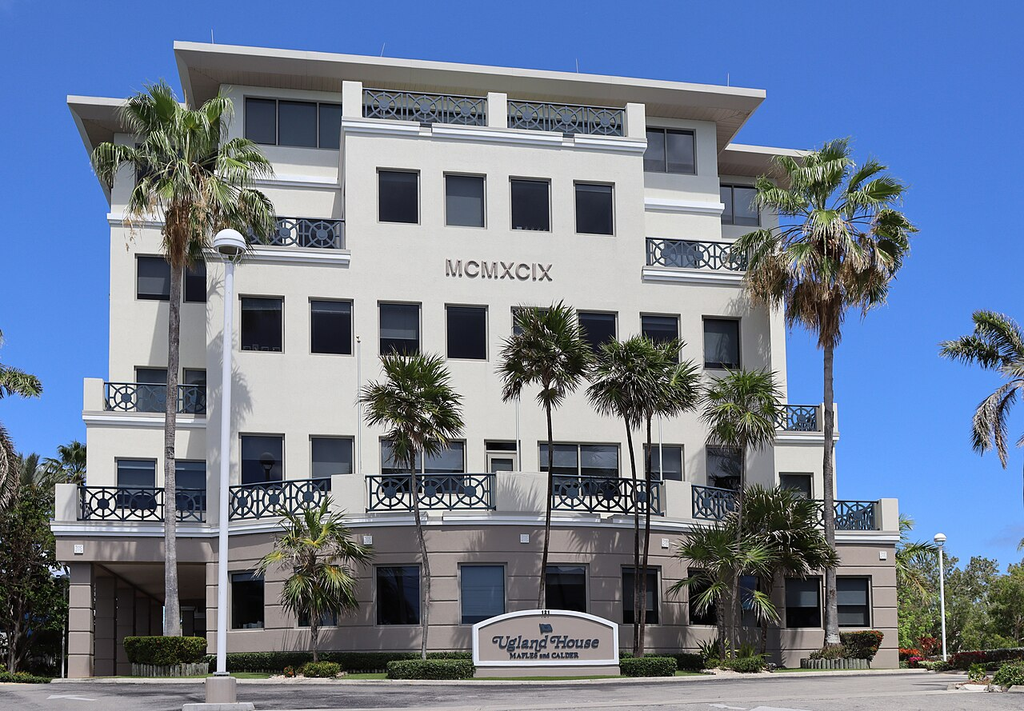

Ugland House, George Town, Cayman Islands: the registered address of thousands of companies.

- The building is real; almost none of those companies trade there
- A haven sells **secrecy and asset protection**, legally
- The account is in a *company’s* name. The bank is required to know who is behind it; **an outsider cannot find out**

Photo: Coolcaesar, Wikimedia Commons, CC BY 4.0.

## Why not keep it at home?

So the official now has **$2.5 million** he cannot explain. Where he puts it decides whether he keeps it.

**A bank at home**

- The account is in **his name**
- An auditor, a journalist, or the next government can find it
- A court can freeze it and order it returned

**A haven, through a company**

- The account is in the **company’s name**
- His own courts cannot simply order it back
- An investigator must first prove the company is his

The stealing happened at home. The haven is what makes it **hard to undo**.

## One official — or a pattern?

That was one contract, and nothing about it was unusual.

- The same chance comes with every large payment an official allocates
- When enough of them take a share, it stops being an anecdote
- **Elite capture:** the people who control public money keep part of it

But we just said you cannot see it at home: the payments reconcile, and the firm’s accounts are private.

So how could anyone **measure** it across a whole country?

## Follow it out of the country

The haven is built to hide the money. But a bank abroad still has to **write the deposit down**, and report its totals.

Which gives us a way in. A national auditor cannot see into those accounts. The international banking record can still count them.

**You know the dates the World Bank paid out. You know what foreign banks report each quarter. Where would you look?**

```
%%{init: {"flowchart": {"useMaxWidth": true, "htmlLabels": false, "nodeSpacing": 45, "rankSpacing": 90, "padding": 45, "curve": "basis"}, "themeVariables": {"fontSize": "22px", "fontFamily": "Helvetica Neue, Helvetica, Arial, sans-serif"}, "width": 1150, "height": 620}}%%
flowchart LR
  A["World Bank sends<br/>aid money"] --> B["Which foreign banks<br/>get new deposits?"]
  B --> C["Secrecy havens<br/>(Switzerland)"]
  B --> D["Ordinary banks<br/>(Germany, Sweden)"]
  C --> E["Deposits jump<br/>that same quarter"]
  D --> F["Deposits don't<br/>move at all"]
  classDef q fill:#1e293b,stroke:#1e293b,stroke-width:2px,color:#ffffff
  classDef hit fill:#b44527,stroke:#1e293b,stroke-width:2px,color:#ffffff
  classDef null fill:#e5e7eb,stroke:#334155,stroke-width:2px,color:#1e293b
  class A,B q
  class C,E hit
  class D,F null
```

Author’s illustration of the research design in Andersen et al. (2022).

## Which pattern would convince you?

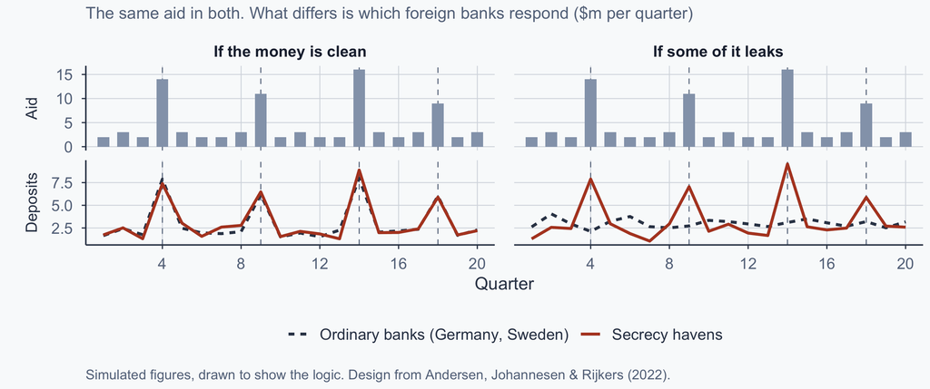

Money goes abroad in both. In the second, **only** where the owner can be hidden.

## Where do these numbers come from?

**Andersen, Johannesen and Rijkers** did exactly this, in the *Journal of Political Economy* (2022). Your required reading. They put two public records side by side.

**The aid:** every World Bank loan and grant is a public record, project by project, month by month. They add it up by country and quarter.

**The deposits:** the **Bank for International Settlements (BIS)** is the central banks’ own bank, in Basel. Banks in **43 financial centres** report to it each quarter what they owe residents of every other country. 17 of those centres are havens.

So a row of this data reads: *this quarter, residents of Tanzania held this much in Swiss banks.* One number, per country pair, per quarter.

The data carry **no names and no account numbers**. You cannot look up the president of anywhere. The authors say so plainly: they “do not observe who stores wealth in havens.”

## The headline result

In the countries that lean most on aid, every **$100** of World Bank money arriving is matched by about **$7.50** more in haven accounts that quarter.

- In the **7 most aid-dependent** countries: more than **$15**
- Deposits in **ordinary** banks, Germany and Sweden, do not move at all

**Before you accept that: what else could do this?** Firms and central banks do hold money abroad.

But that would move Germany too. Only the havens react, and that asymmetry is the argument.

Nobody traced the official’s **$2.5 million**. This is the **shape** such payments leave, counted across a country.

Sample: the 22 countries where aid exceeds 2% of GDP, 1990–2010. The data show deposits, not depositors.

## The more a country leans on aid

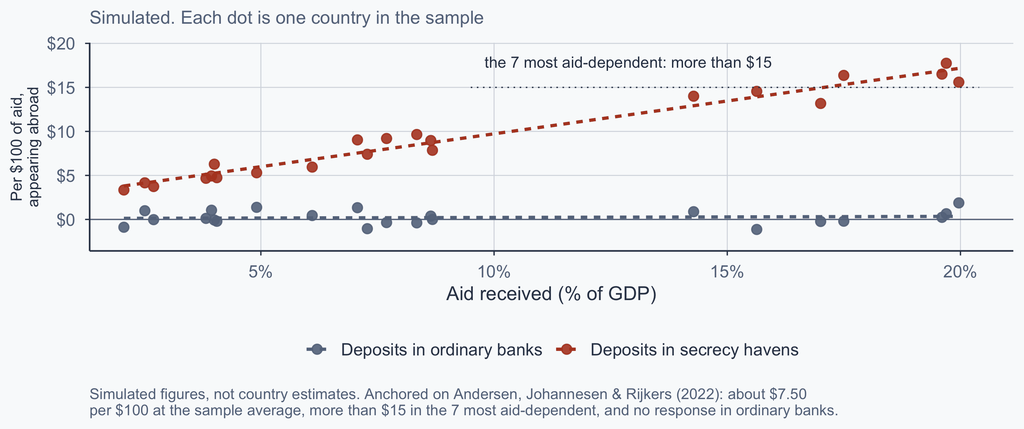

The dots are invented. The **slope** is the finding.

## Exercise 1 — What should donors do?

> In the most aid-dependent countries, roughly 7.5% of a disbursement shows up offshore in the same quarter.

**Pick one position and give your strongest reason:**

1. **Cut aid** to the leakiest countries
2. **Keep aid, add conditions**, and say who verifies them
3. **Change the channel**: bypass the treasury entirely

# III. Where the Money Goes

## ▶ The shell-company industry

[video not shown]

1. Mossack Fonseca wanted to be “the McDonald’s of the offshore system.” What does that tell you about how many of these companies exist?  
2. “You don’t care who actually is behind it.” Whose job was it to care?  
3. Nothing in this clip is a theft. So what exactly was being sold?

Business Insider, “How The Wealthy Hide Billions Using Tax Havens,” featuring Jake Bernstein (ICIJ). Clip 2:21-3:35 of 5:11. Subtitles: ES / EN in the player.

## The answers

1. Mossack Fonseca wanted to be “the McDonald’s of the offshore system.” What does that tell you about how many of these companies exist?

- High volume, low cost, a standard product sold off a shelf. The clip’s own figure: about **214,000** entities in the Panama Papers, roughly half of them registered in the British Virgin Islands

2. “You don’t care who actually is behind it.” Whose job was it to care?

- The firm that formed the company, and the bank that opened its account. Both are required to identify the owner
- The company **registry** usually was not required to ask at all. That gap is what a beneficial-ownership register closes

3. Nothing in this clip is a theft. So what exactly was being sold?

- **Anonymity.** Selling it is lawful. What some buyers go on to do with it is not

## Money in a bank is still evidence

A stolen payment sitting in a bank account is still evidence.

- It can be frozen, traced, and sent back
- To be spent safely it has to look earned
- Property, shares, a company: assets with an innocent explanation

So the money needs a new owner on paper before it can be spent.

Hiding ownership is the whole job.

## What a shell company is

A company that legally exists and does nothing.

- Registered, able to hold an account and own property
- No staff, no premises, no trade
- Its listed owner can be **another company**, in another country

Stack three of those across three jurisdictions and “who owns this money?” has no answer reachable from the outside.

Whoever actually controls it is the **beneficial owner**. Investigators need that name, and the structure exists to withhold it.

## One payment, six steps

```
%%{init: {"flowchart": {"useMaxWidth": true, "htmlLabels": false, "nodeSpacing": 40, "rankSpacing": 70, "padding": 40, "curve": "basis"}, "themeVariables": {"fontSize": "21px", "fontFamily": "Helvetica Neue, Helvetica, Arial, sans-serif"}, "width": 1150, "height": 620}}%%
flowchart LR
  A["Public budget<br/>or aid payment"] --> B["Contract to a<br/>favoured supplier"]
  B --> C["Invoice for work<br/>never done"]
  C --> D["Shell company,<br/>then another"]
  D --> E["Account in a<br/>secrecy jurisdiction"]
  E --> F["Apartment, shares,<br/>yacht abroad"]
  classDef pub fill:#4a7c6f,stroke:#1e293b,stroke-width:2px,color:#ffffff
  classDef cap fill:#b44527,stroke:#1e293b,stroke-width:2px,color:#ffffff
  classDef hid fill:#334155,stroke:#1e293b,stroke-width:2px,color:#ffffff
  classDef ast fill:#b7943a,stroke:#1e293b,stroke-width:2px,color:#ffffff
  class A pub
  class B,C cap
  class D,E hid
  class F ast
```

Only steps 4 and 5 are about secrecy. The money is lost at step 3, in the price.

Author’s illustration. Compare the case typology in van der Does de Willebois et al. (2011).

## Nobody does this alone

Each step needs someone licensed to take it.

- A **formation agent** registers the shells
- A **lawyer** acts as nominee owner, or moves the money through a client account
- An **accountant** signs the invoice
- A **banker** accepts the client and files no report
- An **estate agent** closes on the apartment

None of them needs to see the whole chain. Each step, taken alone, looks like ordinary professional work.

Which is why reform aims here: these are the only people in the chain who are **licensed, insured, and reachable**.

## ▶ The confession of the end of the world

[video not shown]

1. Toledo (president of Peru, 2001–2006) is accused of pocketing **$20 million** to make sure a firm won a highway contract. That is the road we drew earlier. What would its paperwork have looked like?  
2. The money went to right and left, government and opposition — even to the FARC. So what was Odebrecht buying?  
3. It took a plea bargain (a confession traded for a lighter sentence), not an auditor, to reveal any of this — and the prosecutions were in Brazil, the United States and Switzerland. Why those three?

EfectoNaim, “El escandalo del siglo: el caso Odebrecht explicado en 6 minutos” (April 2017). Full video, 6:02. Subtitles: ES / EN in the player.

## The answers (1 of 2)

1. Toledo (president of Peru, 2001–2006) is accused of pocketing **$20 million** to make sure a firm won a highway contract. That is the road we drew earlier. What would its paperwork have looked like?

- Complete. A signed contract, approved invoices, an inspected highway
- The money left the **company’s** account, never the ministry’s. Peru still paid for it, in the price

2. The money went to right and left, government and opposition — even to the FARC. So what was Odebrecht buying?

- Access to whoever ended up awarding the contracts. The policy did not matter, which is why it paid both sides

The video is from 2017, when the Toledo figure was $20 million. He was convicted in Lima in October 2024, on $35 million over two stretches of the Interoceanic Highway, and sentenced to 20 years and 6 months.

## The answers (2 of 2)

3. It took a plea bargain (a confession traded for a lighter sentence), not an auditor, to reveal any of this — and the prosecutions were in Brazil, the United States and Switzerland. Why those three?

- **Why a bargain and not an audit:** a routine audit reconciles payments, and these reconciled. Catching it needed procurement and forensic work, or someone inside with a sentence to shorten
- **Brazil** had the company, and its own officials on the list
- **Switzerland** had the money: the accounts the bribes moved through
- **The United States** had neither, but the bribes were paid in **dollars**, and dollars clear through banks in New York

Notice who is **missing**. The bribes were paid in Peru, Panama, Venezuela and the Dominican Republic, and none of them was at that table. The 2016 resolution came to at least **$3.5 billion**; of Odebrecht’s own fine, Brazil took **80%**, the United States and Switzerland **10%** each.

They have prosecuted their own officials since, one at a time: Toledo in 2024, seven years later.

Braskem’s share, US$957 million, went 70/15/15. U.S. jurisdiction rested on use of the U.S. financial system and on Braskem’s New York listing. Source: U.S. Department of Justice (2016).

## Odebrecht: bribery as a department

Odebrecht ran bribery as a **department**, with its own staff, budget and software.

- The **Division of Structured Operations**, a business unit whose product was paying officials
- Staff opened a program called **MyWebDay** each morning and pulled the day’s list of payments, the way payroll is run
- Instructions went out on **Drousys**, a private messaging system kept off the company’s real network
- **US$788 million** in bribes, 2001–2016, in at least **twelve countries**

The Mexican branch: **Emilio Lozoya**, former director of Pemex, prosecuted for taking Odebrecht money.

The law that reached them: the U.S. **Foreign Corrupt Practices Act** (1977) and the **OECD Anti-Bribery Convention** (1997). Both make bribing a foreign official a crime at home.

Sources: U.S. Department of Justice (2016); International Consortium of Investigative Journalists, *Bribery Division* (2019).

## Why the money rarely comes back

To return it, a prosecutor has to do all of this at once:

- Prove the original act was a crime **where it happened**
- Identify the beneficial owner behind every layer
- Get each jurisdiction in the chain to cooperate, in sequence
- Outlast a defendant who can afford to delay

Any one of them can end it, and the chain was built so that one would.

So the serious proposals are upstream: registers that name owners before anyone is accused, and liability for the professionals who build the layers.

## Takeaways

- A **windfall** is revenue nobody at home had to be asked for, and it draws less scrutiny
- The theft is in the **price**, not the ledger, so a routine audit finds nothing
- Taking it abroad puts it beyond his own courts, and only the havens react when aid arrives. That asymmetry is what makes it countable
- What the industry sells is **anonymity**, lawfully. **Beneficial ownership** is the binding question at every step
- Recovery has to succeed in every jurisdiction at once, so the serious fixes are upstream

And every case we looked at is one that **failed**. The ones that worked leave nothing to study.

Next session: organized crime, and capture backed by the threat of violence.

## References (1 of 2)

Andersen, J. J., Johannesen, N., & Rijkers, B. (2022). Elite capture of foreign aid: Evidence from offshore bank accounts. *Journal of Political Economy, 130*(2), 388-425. https://doi.org/10.1086/717455

International Consortium of Investigative Journalists. (2016). *The Panama Papers.* https://www.icij.org/investigations/panama-papers/

International Consortium of Investigative Journalists. (2019). *Bribery division: What is Odebrecht? Who is involved?* https://www.icij.org/investigations/bribery-division/

OECD. (1997). *Convention on Combating Bribery of Foreign Public Officials in International Business Transactions.* OECD Publishing.

## References (2 of 2)

Svensson, J. (2000). Foreign aid and rent-seeking. *Journal of International Economics, 51*(2), 437-461. https://doi.org/10.1016/S0022-1996(99)00014-8

United States Department of Justice. (2016, December 21). *Odebrecht and Braskem plead guilty and agree to pay at least $3.5 billion in global penalties to resolve largest foreign bribery case in history.* https://www.justice.gov/archives/opa/pr/odebrecht-and-braskem-plead-guilty-and-agree-pay-least-35-billion-global-penalties-resolve

van der Does de Willebois, E., Halter, E. M., Harrison, R. A., Park, J. W., & Sharman, J. C. (2011). *The puppet masters: How the corrupt use legal structures to hide stolen assets.* World Bank / StAR Initiative.

World Bank. (2026). *World development indicators* [Data set]. https://databank.worldbank.org/source/world-development-indicators